# Topic Models

## Student Ratings

It’s that time again: studentratings.byu.edu.

## Example

- One of our new clients, a mid-sized hotel chain, has requested a report on what customers like/dislike about staying at their hotels.
- How would you create this report?
  - Data sources?
  - Methods of analyzing that data?

## Example

- One of our new clients, a mid-sized hotel chain, has requested a report on what customers like/dislike about staying at their hotels.
- How would you create this report?
  - Data sources?
  - Methods of analyzing that data?
- What do we ACTUALLY want to be able to do with this information?

## Translation:

Provide the client with some *actionable* recommendations based on customer sentiment themes.

- **Highlight what is working**: if we find that *staff friendliness* and *location* are viewed positively, these can be featured in our ads.
- **Fix what is broken**: if *noise levels* and *cleanliness* are associated with negative sentiment, these may be areas for operational improvement.

## Marketing Analytics Process

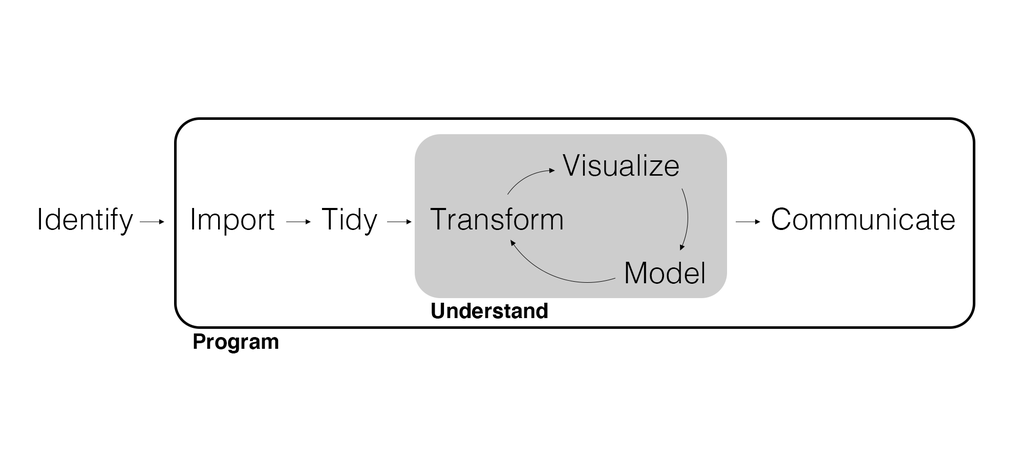

[figure not shown]

## Text Data

We’ve done a bit of **natural language processing** (NLP) previously. The basic approach we’ve already used is called **bag of words**, where each token (what we create when we *tokenize*) is a word.

- Each word is a **token**.
- Each unique word is a **term**.
- A **document** is written by an author.
- A collection of documents is a **corpus**.

By counting the tokens for each term, we produce word counts that we can visualize. We can use word counts to apply *unsupervised learning* techniques to find **topics**.

## Install packages!

- `topicmodels`
- `wordcloud`

## Load Packages

```r
# Load packages.
library(tidyverse)
library(tidytext)
library(topicmodels)
library(dbplyr)
library(DBI)

seed_num <- 42
```

## Import Data

```r
roomba_reviews <- read_csv("roomba_reviews.csv")
```

## Tokenize, Remove Stop Words, and Visualize

Like we did previously, let’s tokenize, remove stop words, and visualize word counts.

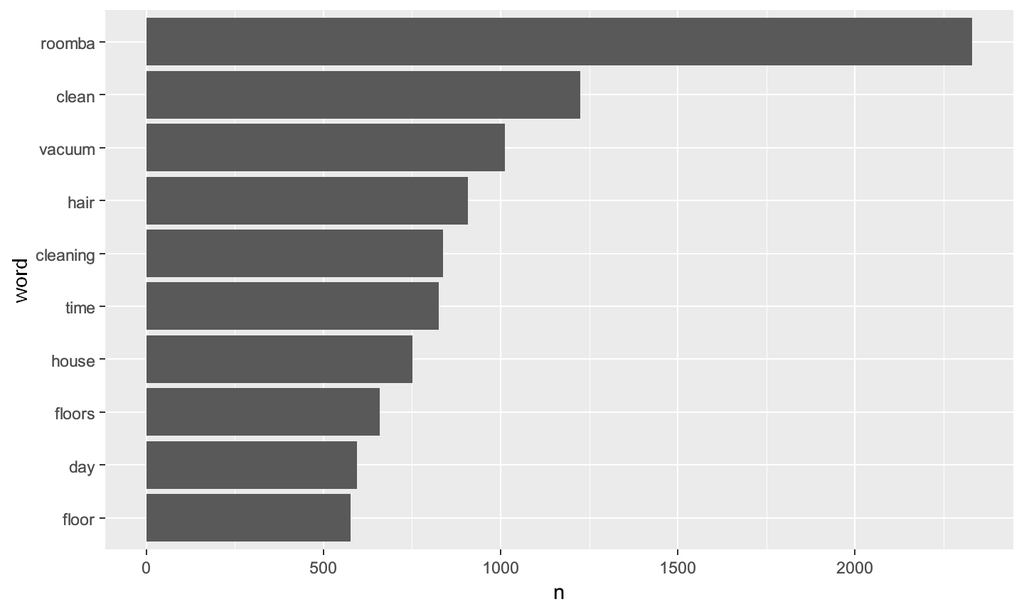

```r
# Tokenize and remove stop words.
tidy_reviews <- roomba_reviews |>
  mutate(review_id = row_number()) |>
  unnest_tokens(word, Review) |>
  anti_join(stop_words, join_by(word))

# Visualize word counts.
tidy_reviews |>
  count(word) |>
  arrange(desc(n)) |>
  slice(1:10) |>
  mutate(word = fct_reorder(word, n)) |>
  ggplot(aes(x = n, y = word)) +
  geom_col()
```

## Word Clouds

Word clouds are just word counts.

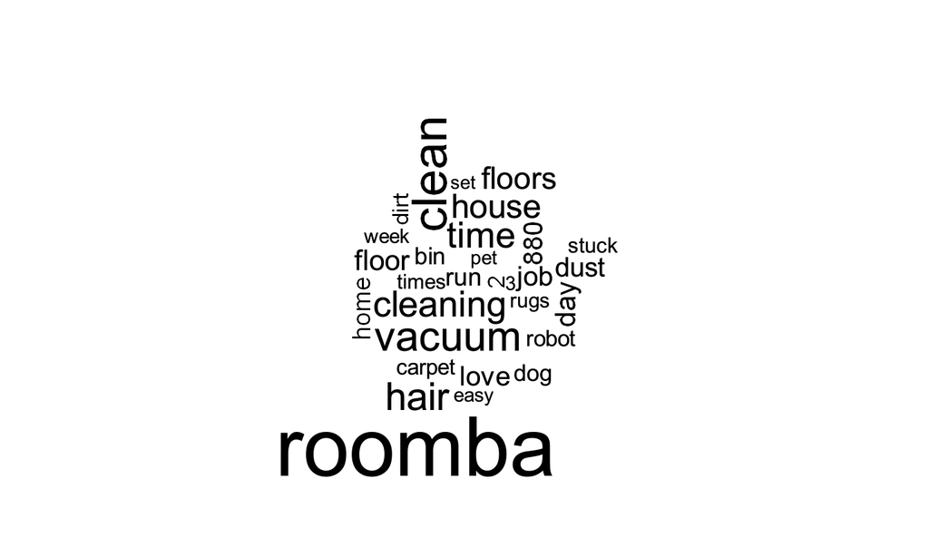

```r
tidy_reviews |>
  count(word) |>
  with(wordcloud::wordcloud(words = word, freq = n, max.words = 30))
```

## Topic Modeling

Word frequencies *suggest* overall meaning, but we would like to uncover the different **topics** being written about. This is especially true as the size of a corpus increases.

- Topic models uncover groups of words (i.e., topics) via *unsupervised learning*.
- The goal is to find *topics* that occur frequently across documents.
- Documents are treated as *mixtures of topics*.
- The most common topic model is called **latent Dirichlet allocation** or LDA.

## Fit LDA

The input for a topic model is a **document term matrix** (DTM). Let’s “cast” our tidy data into a DTM.

```r
# Create a DTM.
dtm_reviews <- tidy_reviews |>
  count(word, review_id) |>
  cast_dtm(review_id, word, n)

dtm_reviews
```

```
## <<DocumentTermMatrix (documents: 1793, terms: 9791)>>
## Non-/sparse entries: 65056/17490207
## Sparsity           : 100%
## Maximal term length: NA
## Weighting          : term frequency (tf)
```

Fitting a topic model is straightforward with a DTM.

```r
# Fit a topic model.
set.seed(seed_num)
fit_lda2 <- dtm_reviews |>
  LDA(k = 2, method = "Gibbs")

fit_lda2
```

```
## A LDA_Gibbs topic model with 2 topics.
```

## Hyperparameter Tuning

We can select a value of `k` by computing the log-likelihood of the data, given the value of `k`. This number represents how likely we would be to observe the documents in our data if the number of topics was truly equal to `k` (the larger the log-likelihood value, the better).

```r
# Tune k.
fit_tune <- tibble(num_topics = 2:10) |>
  mutate(
    fit_lda = pmap(
      list(k = num_topics),
      LDA,
      x = dtm_reviews, method = "Gibbs"
    ),
    model_fit = map(fit_lda, logLik) |> as.numeric()
  )
```

Now we can plot the model fit statistics to determine what `k` might be set to, though it still requires a subjective evaluation of a range of possible models.

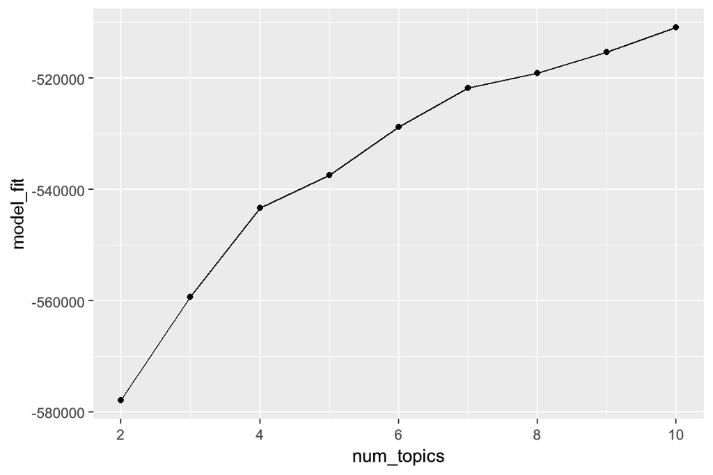

```r
ggplot(fit_tune, aes(x = num_topics, y = model_fit)) +
  geom_point() +
  geom_line()
```

## Evaluate Topics

We will examine the coefficients (betas) from the topic model, which represent the probability that a given word is part of a given topic.

```r
# Fit a final topic model.
fit_lda6 <- dtm_reviews |>
  LDA(k = 6, method = "Gibbs")

# view probabilities.
tidy(fit_lda6, matrix = "beta") |>
  arrange(desc(beta))
```

```
## # A tibble: 58,746 × 3
##    topic term     beta
##    <int> <chr>   <dbl>
##  1     1 roomba 0.149
##  2     3 hair   0.0667
##  3     3 vacuum 0.0522
##  4     6 floors 0.0514
##  5     6 clean  0.0479
##  6     6 love   0.0403
##  7     2 time   0.0360
##  8     6 house  0.0348
##  9     4 clean  0.0330
## 10     3 dog    0.0304
## # ℹ 58,736 more rows
```

Visualize our topics.

```r
fit_lda6 |>
  tidy(matrix = "beta") |>
  group_by(topic) |>
  top_n(8, beta) |>
  ungroup() |>
  mutate(term = reorder_within(term, beta, topic)) |>
  ggplot(aes(x = beta, y = term, fill = as.factor(topic))) +
  geom_col(show.legend = FALSE) +
  facet_wrap(~ topic, scales = "free") +
  scale_y_reordered()
```

How would you name these topics?

[figure not shown]

## Map Documents to Topics

You can examine the reviews assigned to each topic for additional context.

```r
# extract topic classification for each document from the model
# note that documents can contain multiple topics - here we only
# see the most likely
topic_classifications <- tibble(
  doc_number = as.numeric(names(topics(fit_lda6))),
  topic_number = topics(fit_lda6)
)

# join the topic classifications to the original review data
roomba_reviews <- roomba_reviews |>
  mutate(doc_number = 1:n()) |>
  left_join(topic_classifications, join_by(doc_number)) |>
  drop_na(topic_number)
```

Look for documents classified to Topic 6.

```r
roomba_reviews |>
  filter(topic_number == 6) |>
  select(Review)
```

```
## # A tibble: 352 × 1
##    Review
##    <chr>
##  1 Years ago I bought one of the original Roomba's and was underwhelmed - it wa…
##  2 Wow.. I don't know what to say. This thing worked fine for about a week, the…
##  3 Wow, wow, WOW!  I wanted to get one of these a few years ago, but I thought …
##  4 Wow!! is all I can say. I love it!!
##  5 Wow! Now that I don't have to sweep and vacuum up dog hair every day, my lif…
##  6 Worth it even with the hiccups .Pros: no more sweeping , seriously this thin…
##  7 works well. It is very nice to come home to a clean house. We have dark hard…
##  8 Works like a champ. Does its work and goes home to charge. Very cool product…
##  9 Works great. Will get tangled in cords but other than that a great product. …
## 10 Works great! Especially with a new baby. Our time is now worth more. You hav…
## # ℹ 342 more rows
```

Look for documents classified to Topic 2.

```r
roomba_reviews |>
  filter(topic_number == 2) |>
  select(Review)
```

```
## # A tibble: 318 × 1
##    Review
##    <chr>
##  1 "You just walk away and it does the rest"
##  2 "Wow.Wow.  I never knew my floors were so dirty before this!  I've set my \"…
##  3 "Wow, the Roomba is the best christmas gift I've ever gotten.  I have 2 cats…
##  4 "Works well if you turn it on daily and is probably a good substitute to wee…
##  5 "Works Great. Sometimes gets cords tangled so you have to \"childproof cords…
##  6 "Works great. Push the button and head to the store and when you get back yo…
##  7 "With three teens in the house - this is my new best friend!  'Robbie' gets …
##  8 "With 6 dogs, keeping the floors clean was a challenge. The Robot runs every…
##  9 "With 3 cats at home, this robot has been a lifesaver and a blessing. I prog…
## 10 "Wife loves it.  Got points for this purchase.  Turn it on and leave.  When …
## # ℹ 308 more rows
```

## Other Options?

Topic models are great - but do we have another tool that is adept at analyzing large amounts of text?

## Wrapping Up

*Summary*

*Next Time*

- Project week!

*Supplementary Material*

- *Text Mining with R*

## Exercise 15

1. Run a topic model with three topics in `roomba_reviews`.
2. Visualize the topics and name them. Justify your names.
3. Render the Quarto document into Word and upload to Canvas.